# Master document

# Loading data

## Loading packages

```r
library("tidyverse")
```

## Loading data files

```r
blood <- read_csv(here::here(file = "data/_raw/blood.csv"))

tonsil <- read_csv(here::here(file = "data/_raw/tonsil.csv"))

thymus <- read_csv(here::here(file = "data/_raw/thymus.csv"))
```

## Writing data files

```r
write_csv(x = blood,
          file = here::here("data/blood_load.csv"))

write_csv(x = tonsil,
          file = here::here("data/tonsil_load.csv"))

write_csv(x = thymus,
          file = here::here("data/thymus_load.csv"))
```

# Cleaning data

## Loading packages

```r
library("tidyverse")

source(file = here::here("R/99_proj_func.R"))
```

## Loading data files

```r
blood <- read_csv(file = here::here("data/blood_load.csv"))

tonsil <- read_csv(file = here::here("data/tonsil_load.csv"))

thymus <- read_csv(file = here::here("data/thymus_load.csv"))
```

## Cleaning each data set

Each dataset is standardized using the function `pivot_selected_variables()`, which reshapes wide data into a tidy long format. It extracts only the selected variables (`CVQb`, `MedQb`, `PEpos`), splits the variable names into `cell_type` and measurement columns, and tags each observation with its `tissue`. This ensures that all datasets share the same column structure and can be merged later without conflicts.

```r
selected_measures <- c("CVQb", "MedQb", "PEpos")

blood_clean <- blood |>
  pivot_selected_variables(ID_col = "CD",
                           variables = selected_measures,
                           tissue = "blood")


tonsil_clean <- tonsil |>
  pivot_selected_variables(ID_col = "CD",
                           variables = selected_measures,
                           tissue = "tonsil")

thymus_clean <- thymus |>
  pivot_selected_variables(ID_col = "CD",
                           variables = selected_measures,
                           tissue = "thymus")
```

## Merge the three cleaned data sets

Here the cleaned datasets from blood, tonsil, and thymus are combined into one large table (`data_clean`) using `bind_row()`. Control samples labeled `FMO` are filtered out since they are used only for calibration. The result is a clean, uniform dataset containing all immune-cell measurements, ready for further analysis.

```r
data_clean <- bind_rows(blood_clean,
                        tonsil_clean,
                        thymus_clean) |>
  filter(CD != "FMO")
```

## Preparing data set for PCA

The format for a PCA must be wide. As we want to analyse how the cell types cluster based on their CD expression, a variable `cell_type` must be kept. The other variables will then be `CD_measure`, where the measure is either `MedQb` or `PEpos`, which is the opposite of the original wide-format that had `celltype_measure` as variables. As the number of experiments for each CD differs, the mean of all experiments was summarised during the conversion to the wide-format to avoid missing values. However, there was still some missing values due to not all CDs being tested on all cell types. These missing values were assigned with the median for the column, corresponding to the median for that specific CD. We avoided using the mean due to outliers potentially skewing the data.

```r
PCA_clean <- data_clean |>
  pivot_wider(id_cols = c("tissue", "cell_type"),
              names_from = "CD",
              values_from = c("MedQb", "PEpos"),
              values_fn = mean) |>
  mutate(across(
    where(is.numeric),
    ~ if_else(is.na(.x),
              median(.x,
                     na.rm = TRUE),
              .x))
    )
```

## Writing data files

```r
write_csv(x = data_clean,
          file = here::here("data/data_clean.csv"))

write_csv(x = PCA_clean,
          file = here::here("data/PCA_clean.csv"))
```

# Augmenting data

## Loading packages

```r
library("tidyverse")

source(file = here::here("R/99_proj_func.R"))
```

## Loading data files

```r
data_clean <- read_csv(file = here::here("data/data_clean.csv"))

PCA_clean <- read_csv(file = here::here("data/PCA_clean.csv"))
```

## Add variables

Here we enrich the dataset with two new variables:

- hierarchy_level: assigns a numeric level (1–4) describing how specific or mature each cell type is.
- lineage: groups cells into larger categories such as thymocytes, CD4 T cells, CD8 T cells, T cells, or B cells.

These new variables make it easier to visualize and compare immune-cell maturation patterns across tissues.

```r
level_3 <- c("Tgd",
             "TCD8",
             "TCD4",
             "Bnaive",
             "BnatEff",
             "BIgM",
             "BswMem",
             "Bdn",
             "B27high",
             "BnaiveTo",
             "CC",
             "CB",
             "UnswtMem",
             "SwtMem",
             "PC")

data_aug <- data_clean |>
  mutate(hierarchy = case_when(cell_type == "Lymphs" ~ 1,
                               cell_type %in% c("T", "B") ~ 2,
                               cell_type %in% level_3 ~ 3,
                               .default = 4),
         .after = cell_type) |>
  add_lineage()
```

The same lineage classification is applied to the PCA dataset so that both data_aug and PCA_aug share identical labels.

```r
PCA_aug <- PCA_clean |>
  add_lineage()
```

## Writing data files

```r
write_csv(x = data_aug,
          file = here::here("data/data_aug.csv"))

write_csv(x = PCA_aug,
          file = here::here("data/PCA_aug.csv"))
```

# Describing data

## Loading packages

```r
library("tidyverse")
library("table1")

source(file = here::here("R/99_proj_func.R"))
```

## Loading data files

```r
data_aug <- read_csv(file = here::here("data/data_aug.csv"))
```

## Description of the clean data set

The data consists of immunological measurements from blood, tonsil and thymus. The dataset consists of 28340 observations and 8 variables containing CD markers for the cell types in the specific tissue. An overview of the quantitative markers is given below using a `table1` summary of `data_aug` . **The data is structured in long format,** meaning that each combination of `tissue`, `cell_type` and `CD` appears as one row. This structure makes the dataset suitable for analysis and visualization.

```r
data_aug |>
  mutate(tissue = factor(tissue,
                         levels = c("thymus", "tonsil", "blood"),
                         labels = c("Thymus", "Tonsil", "Blood"))) |>
  cell_type_order() |>
  table1(~ CVQb + MedQb + PEpos + cell_type | tissue,
         data = _)
```

|  | Thymus (N=4482) | Tonsil (N=5414) | Blood (N=18444) | Overall (N=28340) |
| --- | --- | --- | --- | --- |
| CVQb |  |  |  |  |
| Mean (SD) | 390 (919) | 147 (259) | 385 (762) | 341 (730) |
| Median [Min, Max] | 147 [17.3, 28800] | 92.2 [0.00134, 5300] | 184 [0.680, 15000] | 150 [0.00134, 28800] |
| Missing | 0 (0%) | 8 (0.1%) | 11 (0.1%) | 19 (0.1%) |
| MedQb |  |  |  |  |
| Mean (SD) | 4770 (18200) | 4730 (9200) | 7150 (21500) | 6310 (19200) |
| Median [Min, Max] | 122 [6.00, 392000] | 1170 [72.8, 88400] | 212 [5.25, 577000] | 453 [5.25, 577000] |
| Missing | 0 (0%) | 8 (0.1%) | 0 (0%) | 8 (0.0%) |
| PEpos |  |  |  |  |
| Mean (SD) | 33.1 (42.0) | 23.2 (34.0) | 32.4 (39.0) | 30.8 (38.8) |
| Median [Min, Max] | 4.60 [0.000507, 100] | 2.53 [0.00240, 100] | 8.09 [0.00143, 117] | 6.37 [0.000507, 117] |
| Missing | 1 (0.0%) | 158 (2.9%) | 5 (0.0%) | 164 (0.6%) |
| cell_type |  |  |  |  |
| DN34p | 498 (11.1%) | 0 (0%) | 0 (0%) | 498 (1.8%) |
| DN34m1ap | 498 (11.1%) | 0 (0%) | 0 (0%) | 498 (1.8%) |
| CD4ISP | 498 (11.1%) | 0 (0%) | 0 (0%) | 498 (1.8%) |
| DP3m | 498 (11.1%) | 0 (0%) | 0 (0%) | 498 (1.8%) |
| DP3p | 498 (11.1%) | 0 (0%) | 0 (0%) | 498 (1.8%) |
| CD4SP1ap | 498 (11.1%) | 0 (0%) | 0 (0%) | 498 (1.8%) |
| CD4SP1am | 498 (11.1%) | 0 (0%) | 0 (0%) | 498 (1.8%) |
| CD8SP1ap | 498 (11.1%) | 0 (0%) | 0 (0%) | 498 (1.8%) |
| CD8SP1am | 498 (11.1%) | 0 (0%) | 0 (0%) | 498 (1.8%) |
| BnaiveTo | 0 (0%) | 701 (12.9%) | 0 (0%) | 701 (2.5%) |
| CC | 0 (0%) | 701 (12.9%) | 0 (0%) | 701 (2.5%) |
| CB | 0 (0%) | 701 (12.9%) | 0 (0%) | 701 (2.5%) |
| UnswtMem | 0 (0%) | 701 (12.9%) | 0 (0%) | 701 (2.5%) |
| SwtMem | 0 (0%) | 701 (12.9%) | 0 (0%) | 701 (2.5%) |
| PC | 0 (0%) | 698 (12.9%) | 0 (0%) | 698 (2.5%) |
| CD138negPC | 0 (0%) | 698 (12.9%) | 0 (0%) | 698 (2.5%) |
| CD138posPC | 0 (0%) | 513 (9.5%) | 0 (0%) | 513 (1.8%) |
| Lymphs | 0 (0%) | 0 (0%) | 882 (4.8%) | 882 (3.1%) |
| T | 0 (0%) | 0 (0%) | 882 (4.8%) | 882 (3.1%) |
| Tgd | 0 (0%) | 0 (0%) | 822 (4.5%) | 822 (2.9%) |
| TCD4 | 0 (0%) | 0 (0%) | 882 (4.8%) | 882 (3.1%) |
| TCD4naive | 0 (0%) | 0 (0%) | 882 (4.8%) | 882 (3.1%) |
| TCD4CM | 0 (0%) | 0 (0%) | 882 (4.8%) | 882 (3.1%) |
| TCD4EM | 0 (0%) | 0 (0%) | 882 (4.8%) | 882 (3.1%) |
| TCD4TEMRA | 0 (0%) | 0 (0%) | 880 (4.8%) | 880 (3.1%) |
| TCD8 | 0 (0%) | 0 (0%) | 882 (4.8%) | 882 (3.1%) |
| TCD8naive | 0 (0%) | 0 (0%) | 882 (4.8%) | 882 (3.1%) |
| TCD8CM | 0 (0%) | 0 (0%) | 881 (4.8%) | 881 (3.1%) |
| TCD8EM | 0 (0%) | 0 (0%) | 881 (4.8%) | 881 (3.1%) |
| TCD8TEMRA | 0 (0%) | 0 (0%) | 882 (4.8%) | 882 (3.1%) |
| TCD8RAdim | 0 (0%) | 0 (0%) | 882 (4.8%) | 882 (3.1%) |
| B | 0 (0%) | 0 (0%) | 882 (4.8%) | 882 (3.1%) |
| Bnaive | 0 (0%) | 0 (0%) | 881 (4.8%) | 881 (3.1%) |
| BnatEff | 0 (0%) | 0 (0%) | 882 (4.8%) | 882 (3.1%) |
| BIgM | 0 (0%) | 0 (0%) | 877 (4.8%) | 877 (3.1%) |
| BswMem | 0 (0%) | 0 (0%) | 879 (4.8%) | 879 (3.1%) |
| Bdn | 0 (0%) | 0 (0%) | 880 (4.8%) | 880 (3.1%) |
| B27high | 0 (0%) | 0 (0%) | 879 (4.8%) | 879 (3.1%) |

## Quantifying data set diversity

Using the `summarise()` function, we count the number of unique CD markers and cell types present in the data

```r
data_aug |>
  summarise(n_CDs = n_distinct(CD),
            n_celltypes = n_distinct(cell_type))
```

```
# A tibble: 1 × 2
  n_CDs n_celltypes
  <int>       <int>
1   114          38
```

# Analysis 1

## Loading packages

```r
library("tidyverse")
library("broom")
library("ggrepel")
library("patchwork")

source(file = here::here("R/99_proj_func.R"))
```

## Loading data files

```r
PCA_aug <- read_csv(file = here::here("data/PCA_aug.csv"))
```

## Make the PCA fit

The data is split into two data sets, one for MedQb and for PEpos, so we can make a PCA for each.

```r
data_MedQb <- PCA_aug |>
  select(tissue,
         cell_type,
         lineage,
         starts_with("MedQb"))

data_PEpos <- PCA_aug |>
  select(tissue,
         cell_type,
         lineage,
         starts_with("PEpos"))
```

After all set is split up we use the function `prcomp` was used to make the the PCA.

```r
PCA_fit_MedQb <- data_MedQb |>
  select(where(is.numeric)) |>
  prcomp(scale = TRUE)

PCA_fit_PEpos <- data_PEpos |>
  select(where(is.numeric)) |>
  prcomp(scale = TRUE)
```

## Make the plot

On the plot we have PC1 on the x-axis and PC2 on the y-axis. Usually most variation can be captured with the first two principal components. The points are stratified using tissue type (blood, tonsil, thymus) as the shapes and cell lineage as the color.

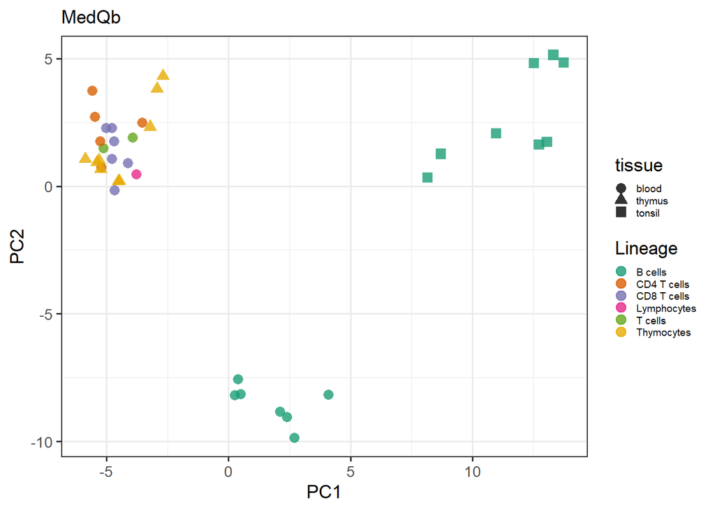

```r
scatter_plot_MedQb <- PCA_fit_MedQb |>
  PCA_plot(data = data_MedQb,
           subtitle = "MedQb")

scatter_plot_MedQb
```

Then for PEpos:

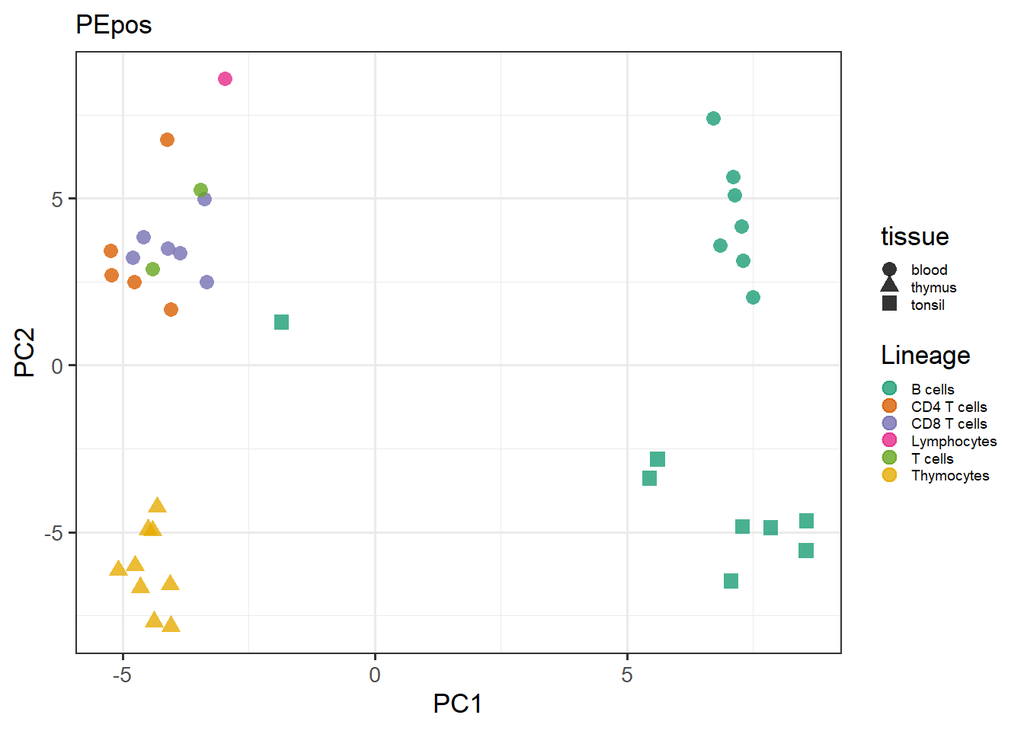

```r
scatter_plot_PEpos <- PCA_fit_PEpos |>
  PCA_plot(data = data_PEpos,
           subtitle = "PEpos")

scatter_plot_PEpos
```

## Rotation matrices

These were made but ultimately it was a dead end.

**MedQb - all variables:**

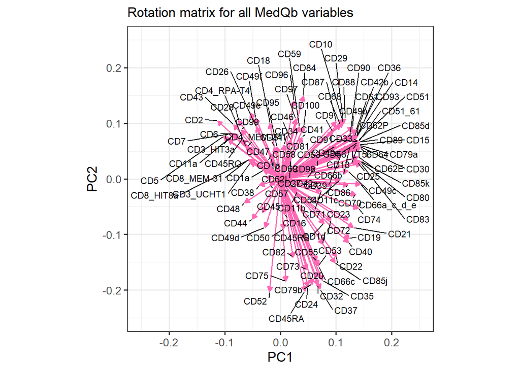

```r
PCA_fit_MedQb |>
  PCA_rotation(prefix = "MedQb_",
               amount = Inf,
               xlimits = c(-0.25, 0.25),
               ylimits = c(-0.25, 0.25),
               subtitle   = "Rotation matrix for all MedQb variables")
```

**MedQb - top 10 variables:**

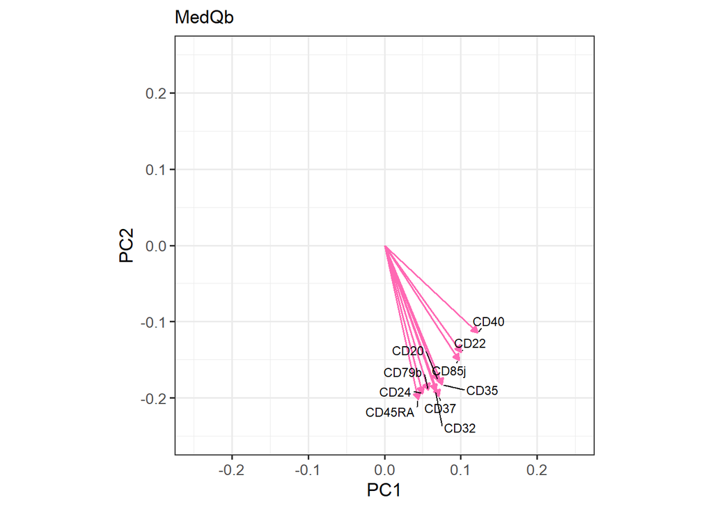

```r
PCA_fit_MedQb |>
  PCA_rotation(prefix = "MedQb_",
               amount = 10,
               xlimits = c(-0.25, 0.25),
               ylimits = c(-0.25, 0.25),
               subtitle   = "MedQb")
```

**PEpos - all variables:**

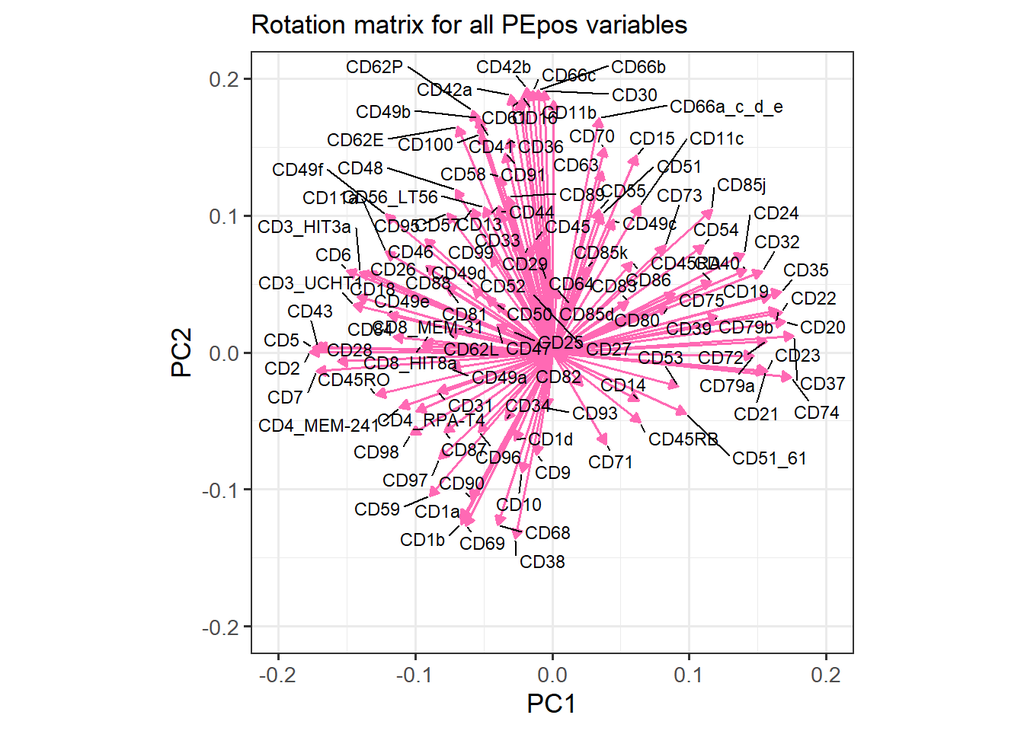

```r
PCA_fit_PEpos |>
  PCA_rotation(prefix = "PEpos_",
               amount = Inf,
               xlimits = c(-0.2, 0.2),
               ylimits = c(-0.2, 0.2),
               subtitle = "Rotation matrix for all PEpos variables")
```

**PEpos - top 10 variables:**

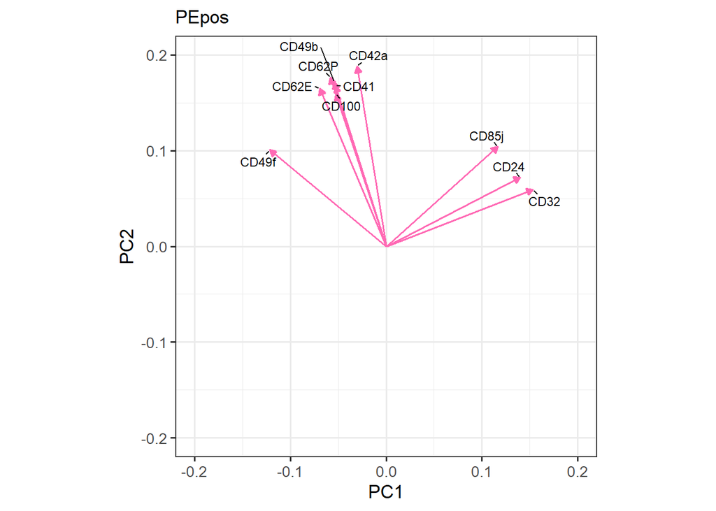

```r
PCA_fit_PEpos |>
  PCA_rotation(prefix = "PEpos_",
               amount = 10,
               xlimits = c(-0.2, 0.2),
               ylimits = c(-0.2, 0.2),
               subtitle = "PEpos")
```

## Plot export

```r
scatter_plot_MedQb <- scatter_plot_MedQb +
    labs(title = "PCA plot stratified on tissue and lineage")

final_plot <- scatter_plot_MedQb / scatter_plot_PEpos

save_plot(plot = final_plot,
          filename = "05_key_plot.png",
          width = 8,
          height = 9)
```

# Analysis 2

## Loading packages

```r
library("tidyverse")

source(file = here::here("R/99_proj_func.R"))
```

## Loading data files

```r
data_aug <- read_csv(file = here::here("data/data_aug.csv"))
```

## Creating auxiliary data frame

The **aim** of this visualization is to have a summarized, comprehensive view of all CD markers used in our data set. From it, the user can extract preliminary insight about constitutive, cohort- and tissue-associated markers, which will be further expanded in following analyses.

A dummy variable `tube_bar` (with the value `"TubeBar"`) is added to enable plotting a horizontal bar above the plot for identifying `cell_type` by `tissue`.

```r
data_aug <- data_aug |>
  mutate(tube_bar = "TubeBar")
```

## Making the heat dot plot

As the same plot will be used many times, albeit with slight alterations, a function called `heat_dot_plot()` has been created separately and placed in `R/99_proj_func.R`. Our data set, `data_aug` was slightly modified for the analysis; new columns with labels for CD number and tissue were added to allow for correct alphabetical display of CD markers using the custom function `CD_order()`. Additionally, `tube_bar` is plotted over the upper x-axis. Discrete intervals for dot size are displayed in the legend for a comprehensive view of the plot, as well as a color gradient bar for fluorescence.

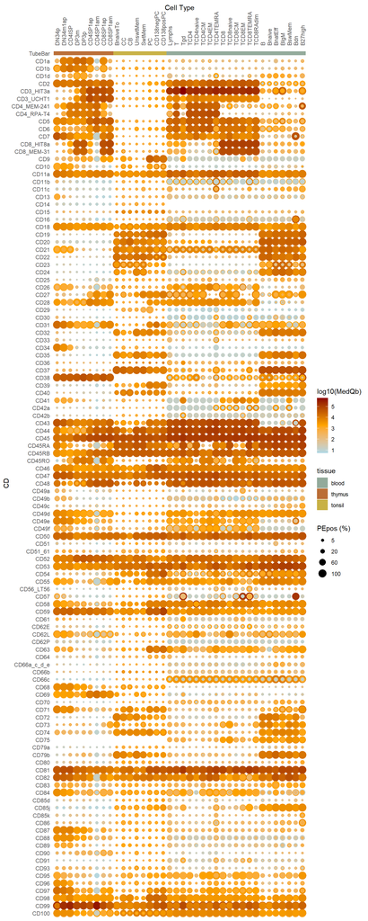

```r
data_aug |>
  drop_na(MedQb, PEpos) |>
  cell_type_order() |>
  heat_dot_plot()
```

As the plot figure is too large for the presentation, a subset of `data_aug` will be used for showing data points of interest.

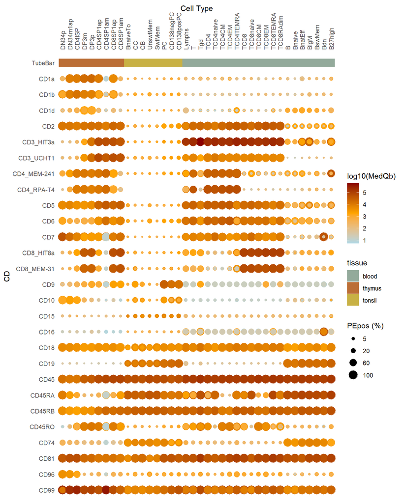

```r
CDs <- c(1,2,3,4,5,6,7,8,9,10, 15, 16, 17, 18, 19, 45, 74, 81, 96, 99)

final_plot <- data_aug |>
  mutate(CD_num = parse_number(CD)) |>
  filter(CD_num %in% CDs) |>
  drop_na(MedQb, PEpos) |>
  cell_type_order() |>
  heat_dot_plot()

final_plot
```

## Export plots

```r
save_plot(plot = final_plot,
          filename = "06_key_plot.png",
          width = 11,
          height = 7)
```

# Analysis 3

## Loading packages

```r
library("tidyverse")
library("scales")
library("patchwork")
library("broom")
library("rlang")

source(here::here("R", "99_proj_func.R"))
```

## Loading data files

```r
data_aug <- read_csv(here::here("data", "data_aug.csv"))
```

## Correlation of MedQb to CVQb and PEpos

The purpose of these plots is to examine and compare the fluorescence signals across key immune cell types and tissues.

### Flourescence of B cells in blood

Firstly, boxplots of `MedQb`, `CVQb` and `PEpos` based on `CD` are created in ascending order of `MedQb` for `B cells` in the `blood`.

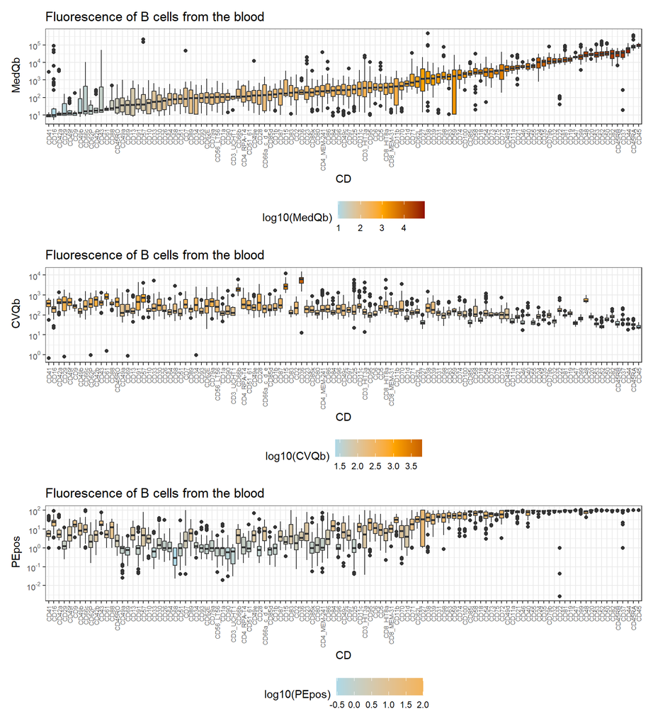

```r
p1 <- data_aug |>
  asc_CDs_boxplot(lineage_filter = "B cells",
                  hierarchy_filter = 3,
                  tissue_filter = "blood",
                  measure = MedQb)

p2 <- data_aug |>
  asc_CDs_boxplot(lineage_filter = "B cells",
                  hierarchy_filter = 3,
                  tissue_filter = "blood",
                  measure = CVQb)

p3 <- data_aug |>
  asc_CDs_boxplot(lineage_filter = "B cells",
                  hierarchy_filter = 3,
                  tissue_filter = "blood",
                  measure = PEpos)

p1 / p2 / p3
```

From the plots, it looks like that there might be a correlation between the three variables. When the `MedQb` increases, the `CVQb` seems to decrease. For `PEpos` the correlation does not seem as strong, but it may increase, when `MedQb` increases.

## Applying a linear model

In the next part, the two correlations are assessed by creating a linear model of the two variables, `CVQb` and `PEpos`, against `MedQb`. Additionally, the correlation coefficients are calculated. The logarithmic values are used.

```r
columns <- c("tissue",
             "lineage",
             "term_CVQb",
             "estimate_CVQb",
             "term_PEpos",
             "estimate_PEpos")

data_lm <- data_aug |>
  filter(lineage != "T cells",
         !hierarchy %in% c(1, 2)) |>
  group_by(tissue, lineage) |>
  nest() |>
  mutate(model_object_CVQb = map(.x = data,
                   .f = ~lm(formula = log(MedQb) ~ log(CVQb),
                            data = .x)),
         model_object_PEpos = map(.x = data,
                   .f = ~lm(formula = log(MedQb) ~ log(PEpos),
                            data = .x))) |>
  mutate(model_object_tidy_CVQb = map(.x = model_object_CVQb,
                                 .f = ~tidy(.x,
                                           conf.int = TRUE,
                                           conf.level = 0.95)),
         model_object_tidy_PEpos = map(.x = model_object_PEpos,
                                 .f = ~tidy(.x,
                                           conf.int = TRUE,
                                           conf.level = 0.95))) |>
  unnest(model_object_tidy_CVQb,
         model_object_tidy_PEpos) |>
  rename(term_CVQb = "term",
         term_PEpos = "term1",
         estimate_CVQb = "estimate",
         estimate_PEpos = "estimate1") |>
  select(columns) |>
  ungroup() |>
  mutate(
    term_CVQb = case_when(
      term_CVQb == "(Intercept)" ~ "intercept",
      term_CVQb != "(Intercept)" ~ "slope"),
    term_PEpos = case_when(
      term_PEpos == "(Intercept)" ~ "intercept",
      term_PEpos != "(Intercept)" ~ "slope")) |>
  pivot_longer(cols = c(term_CVQb, term_PEpos, estimate_CVQb, estimate_PEpos),
                        names_to = c(".value", "measure"),
                        names_pattern = "(.*)_(.*)") |>
  mutate(measure = str_remove(measure, "term_")) |>
  pivot_wider(id_cols = c("tissue", "lineage"),
              names_from = c("measure", "term"),
              values_from = estimate)
```

The correlation coefficient is now calculated and the two data frames are joined.

```r
data_params <- data_aug |>
  filter(!is.na(MedQb),
         !is.na(CVQb),
         !is.na(PEpos),
         lineage != "T cells",
         !hierarchy %in% c(1, 2)) |>
  group_by(tissue, lineage) |>
  summarise(CVQb_cor = cor(log(CVQb), log(MedQb)),
            PEpos_cor = cor(log(PEpos), log(MedQb))) |>
  left_join(y = data_lm,
            by = c("tissue", "lineage"),
            relationship = "one-to-one")
```

In the last part, scatter plots with the linear model are created.

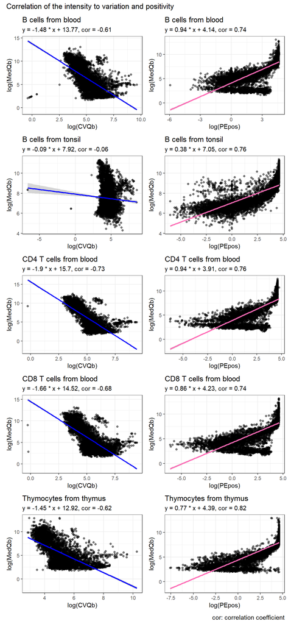

```r
p1 <- data_aug |>
  plot_scatter(params = data_params,
               measure = CVQb,
               lineage_filter = "B cells",
               tissue_filter = "blood",
               color = "blue")


p2 <- data_aug |>
  plot_scatter(params = data_params,
               measure = PEpos,
               lineage_filter = "B cells",
               tissue_filter = "blood",
               color = "hotpink")

p3 <- data_aug |>
  plot_scatter(params = data_params,
               measure = CVQb,
               lineage_filter = "B cells",
               tissue_filter = "tonsil",
               color = "blue")

p4 <- data_aug |>
  plot_scatter(params = data_params,
               measure = PEpos,
               lineage_filter = "B cells",
               tissue_filter = "tonsil",
               color = "hotpink")

p5 <- data_aug |>
  plot_scatter(params = data_params,
               measure = CVQb,
               lineage_filter = "CD4 T cells",
               tissue_filter = "blood",
               color = "blue")

p6 <- data_aug |>
  plot_scatter(params = data_params,
               measure = PEpos,
               lineage_filter = "CD4 T cells",
               tissue_filter = "blood",
               color = "hotpink")

p7 <- data_aug |>
  plot_scatter(params = data_params,
               measure = CVQb,
               lineage_filter = "CD8 T cells",
               tissue_filter = "blood",
               color = "blue")

p8 <- data_aug |>
  plot_scatter(params = data_params,
               measure = PEpos,
               lineage_filter = "CD8 T cells",
               tissue_filter = "blood",
               color = "hotpink")

p9 <- data_aug |>
  plot_scatter(params = data_params,
               measure = CVQb,
               lineage_filter = "Thymocytes",
               tissue_filter = "thymus",
               color = "blue")

p10 <- data_aug |>
  plot_scatter(params = data_params,
               measure = PEpos,
               lineage_filter = "Thymocytes",
               tissue_filter = "thymus",
               color = "hotpink")

final_plot <- (p1 + p2) / (p3 + p4) / (p5 + p6) / (p7 + p8) / (p9 + p10) +
  plot_annotation(
    title = "Correlation of the intensity to variation and positivity",
    caption = "cor: correlation coefficient") &
  theme(plot.caption = element_text(size = 11))

final_plot
```

## Plot export

```r
save_plot(plot = final_plot,
          filename = "07_key_plot.png",
          width = 7.5,
          height = 9)
```

# Analysis 4

## Loading packages

```r
library("tidyverse")
library("broom")
library("patchwork")

source(here::here(file = "R/99_proj_func.R"))
```

## Loading data files

```r
data_aug <- read_csv(here::here(file = "data/data_aug.csv"))
```

The aim of this analysis is to explore how different CD markers change across immune cell types and maturation stages in several tissues, using linear models and simple visualizations to highlight meaningful differences.

## Maturation of immune cells

This part prepares the data and runs the linear models. We keep only the detailed cell-type levels we care about and remove some unwanted columns and populations. After cleaning, we group the data by tissue, CD marker, and lineage, and then fit a linear model (`log(MedQb) ~ cell_type`) for each group.  
Once the models are fit, we classify whether each term is significant, rebuild the cell-type names, and adjust estimates by adding the intercept back in so everything stays on the same scale.

```r
columns <- c("CD",
             "tissue",
             "lineage",
             "cell_type",
             "estimate",
             "conf.low",
             "conf.high",
             "p.value",
             "is_significant")

data_analysis4 <- data_aug |>
  cell_type_order() |>
  filter(hierarchy %in% c(3, 4),
         !cell_type %in% c("Tgd", "TCD4", "TCD8")) |>
  select(-c("CVQb", "PEpos")) |>
  drop_na(MedQb) |>
  group_by(tissue, CD, lineage) |>
  filter(n() > n_distinct(cell_type)) |>
  fit_linear_model(log(MedQb) ~ cell_type)|>
  mutate(is_significant = case_when(term == "(Intercept)" ~ "reference",
                                    p.value < 0.05 ~ "yes",
                                    p.value >= 0.05 ~ "no")) |>
  mutate(
    intercept = estimate[term == "(Intercept)"],
    estimate = case_when(
      term == "(Intercept)" ~ estimate,
      term != "(Intercept)" ~ estimate + intercept),
    conf.low = case_when(
      term == "(Intercept)" ~ conf.low,
      term != "(Intercept)" ~ conf.low + intercept),
    conf.high = case_when(
      term == "(Intercept)" ~ conf.high,
      term != "(Intercept)" ~ conf.high + intercept),
    cell_type = case_when(
      term == "(Intercept)" & tissue == "blood" & lineage == "B cells" ~ "Bnaive",
      term == "(Intercept)" & tissue == "tonsil" ~ "BnaiveTo",
      term == "(Intercept)" & lineage == "CD4 T cells" ~ "TCD4naive",
      term == "(Intercept)" & lineage == "CD8 T cells" ~ "TCD8naive",
      term == "(Intercept)" & tissue == "thymus"  ~ "DN34p",
    .default = str_remove(term, "cell_type"))) |>
  select(all_of(columns)) |>
  ungroup()
```

The results are then combined into a single table called data_analysis4, which serves as the base for visualization and further interpretation. The function `plot_cd_expression()` is used to visualize these model results, plotting the estimated expression levels and their confidence intervals for each CD marker across tissues and cell types.

## Significant CDs

Here we check which CD markers actually show significant differences between cell types.  
We filter for terms with p < 0.05, count how many CDs are significant within each lineage.

```r
cds_significant <- data_analysis4 |>
  filter(is_significant == "yes") |>
  group_by(lineage) |>
  summarise(n_significant_CDs = n_distinct(CD)) |>
  arrange(desc(n_significant_CDs))

cds_significant
```

```
# A tibble: 4 × 2
  lineage     n_significant_CDs
  <chr>                   <int>
1 B cells                   104
2 Thymocytes                 74
3 CD4 T cells                51
4 CD8 T cells                46
```

A column plot of the count of significant CDs for each lineage is created below.

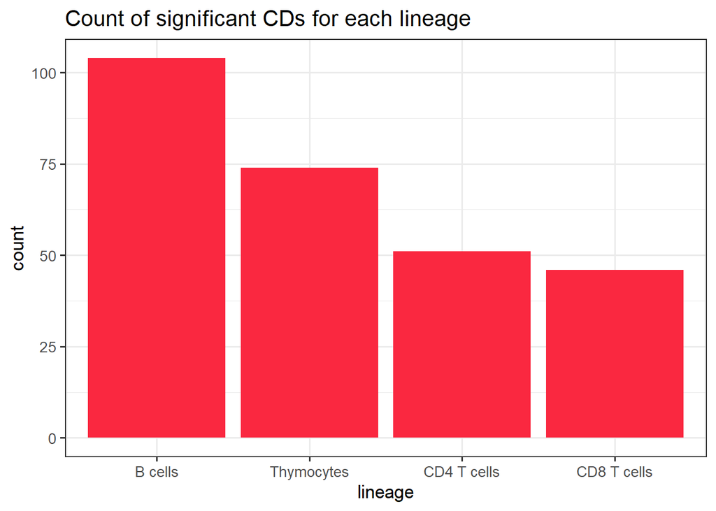

```r
sig_CD_count <- data_analysis4 |>
  plot_sig_CDs(by_variable = lineage,
                 fill_color = "#fa2840")


sig_CD_count
```

## B cells

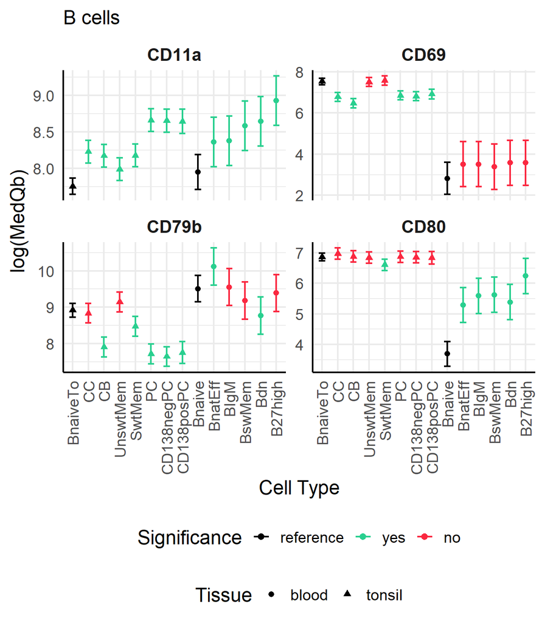

```r
cds_interest_b <- c("CD11a", "CD69", "CD79b", "CD80")

p1 <- data_analysis4 |>
  plot_cd_expression(lineage_filter = "B cells",
                     cds = cds_interest_b,
                     subtitle = "B cells")

p1
```

**B cell markers:** CD11a (cell adhesion), CD69 (early activation), CD79b (B cell receptor signaling), CD80 (co-stimulation).

## T cells

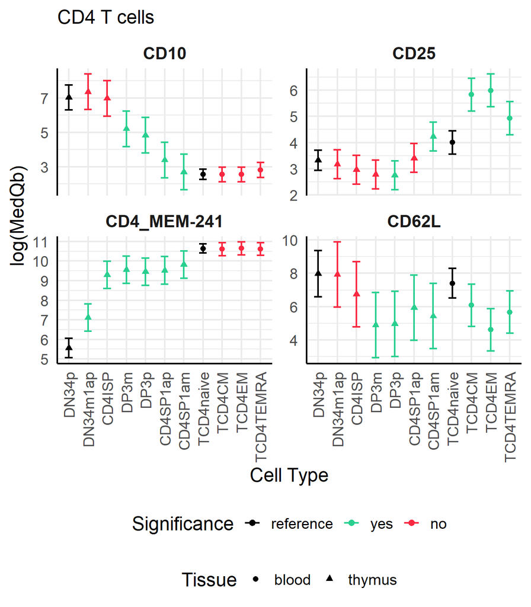

```r
cds_interest_cd4 <- c("CD10", "CD25", "CD4_MEM-241", "CD62L")

p2 <- data_analysis4 |>
  plot_cd_expression(lineage_filter = c("Thymocytes", "CD4 T cells"),
                     cds = cds_interest_cd4,
                     cell_type_exclude = "CD8",
                     subtitle = "CD4 T cells")

p2
```

**CD4 T cell markers:** CD10 (early maturation), CD25 (activation), CD4_MEM-241 (memory), CD62L (migration).

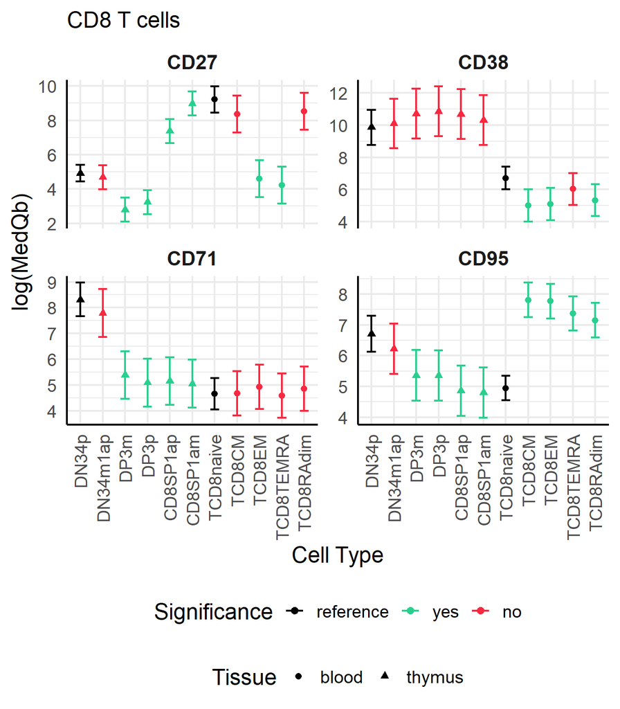

```r
cds_interest_cd8 <- c("CD27", "CD38", "CD71", "CD95")

p3 <- data_analysis4 |>
  plot_cd_expression(lineage_filter = c("Thymocytes", "CD8 T cells"),
                     cds = cds_interest_cd8,
                     cell_type_exclude = "CD4",
                     subtitle = "CD8 T cells")

p3
```

**CD8 T cell markers:** CD27 (memory), CD38 (activation), CD71 (proliferation), CD95 (apoptosis).

## Export plots

```r
save_plot(plot = sig_CD_count,
          filename = "08_key_plot_1.png")

p1 <- p1 +
  labs(title = "Selected significant CDs during maturation stratified on lineage")

final_plot <- p1 + p2 + p3

save_plot(plot = final_plot,
          filename = "08_key_plot_2.png",
          width = 22,
          height = 9)
```

# Analysis 5

## Loading packages

```r
library("tidyverse")
library("broom")
library("patchwork")

source(here::here("R", "99_proj_func.R"))
```

## Loading data files

```r
data_aug <- read_csv(file = here::here("data/data_aug.csv"))
```

## Differences in CD makers on CD4 and CD8 T cells

In the data set, the `CD4 T cells` and `CD8 T cells` exist in two similar and parallel subsets in the `thymus`, `SP1ap` and `SP1am`, and four subsets in the `blood`, `naive`, `central memory` (CM) `effector memory` (EM) and `TEMRA`. It is therefore interesting to investigate differences in CD marker expression between `CD4` and `CD8` T cells for each pair of subset.

## Applying a linear model

To assess significant differences in CD marker expression between each pair, a linear model was applied using the `map()` function as described in analysis 4. In order to compare the CDs for a specific subset between `CD4` and `CD8`, the data must be grouped by the pair, hence why the variable `pair` was added. As the `CD4 T cells` are listed first in the function `cell_type_order`, their estimate corresponds the intercept, while the estimate of the `CD8 T cells` is the slope, corresponding to how much the CD expression differs from the `CD4 T cells`. Lastly, the full estimates were calculated by adding the intercept to the estimate of the `CD8 T cells`, and the variable `is_significant` and `any_significant` is added from the calculated p-value. The step `filter(n() > n_distinct(cell_type))` is added to ensure more than one observation for each `cell_type` in each `pair`.

```r
columns <- c("tissue",
             "CD",
             "cell_type",
             "pair",
             "estimate",
             "conf.low",
             "conf.high",
             "p.value",
             "is_significant")

data_analysis5  <- data_aug |>
  filter(str_detect(cell_type, "CD4") | str_detect(cell_type, "CD8"),
         cell_type != "CD4ISP",
         cell_type != "TCD8RAdim",
         hierarchy == 4) |>
  select(-c("CVQb", "PEpos")) |>
  drop_na(MedQb) |>
  mutate(pair = case_when(str_detect(cell_type, "SP1ap") ~ "SP1ap",
                          str_detect(cell_type, "SP1am") ~ "SP1am",
                          str_ends(cell_type, "naive") ~ "naive",
                          str_ends(cell_type, "CM") ~ "CM",
                          str_ends(cell_type, "EM") ~ "EM",
                          str_detect(cell_type, "TEMRA") ~ "TEMRA"),
         .before = cell_type) |>
  group_by(tissue, CD, pair) |>
  filter(n() > n_distinct(cell_type)) |>
  fit_linear_model(log(MedQb) ~ cell_type)|>
  mutate(is_significant = case_when(
    p.value[term != "(Intercept)"] < 0.05 ~ "yes",
    p.value[term != "(Intercept)"] >= 0.05 ~ "no")) |>
  mutate(
    intercept = estimate[term == "(Intercept)"],
    estimate = case_when(
      term == "(Intercept)" ~ estimate,
      term != "(Intercept)" ~ estimate + intercept),
    conf.low = case_when(
      term == "(Intercept)" ~ conf.low,
      term != "(Intercept)" ~ conf.low + intercept),
    conf.high = case_when(
      term == "(Intercept)" ~ conf.high,
      term != "(Intercept)" ~ conf.high + intercept),
    cell_type = case_when(
      term == "(Intercept)" & pair == "SP1ap" ~ "CD4SP1ap",
      term == "(Intercept)" & pair == "SP1am" ~ "CD4SP1am",
      term == "(Intercept)" & pair == "naive" ~ "TCD4naive",
      term == "(Intercept)" & pair == "CM" ~ "TCD4CM",
      term == "(Intercept)" & pair == "EM" ~ "TCD4EM",
      term == "(Intercept)" & pair == "TEMRA" ~ "TCD4TEMRA",
      .default = str_remove(term, "cell_type"))) |>
  select(all_of(columns)) |>
  ungroup() |>
  mutate(lineage = case_when(str_detect(cell_type, "CD4") ~ "CD4 T cells",
                             .default = "CD8 T cells"),
         .before = cell_type)
```

## Count of significant CDs

Below are the number of significant CDs for each pair calculated and visualized.

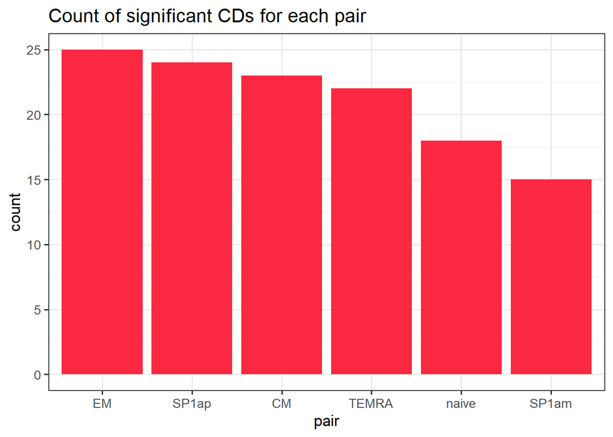

```r
sig_CD_count <- data_analysis5 |>
  plot_sig_CDs(by_variable = pair,
                 fill_color = "#fa2840")


sig_CD_count
```

## Visualization of significant CDs between each pair

The significant CDs for each pair are visualized with an error bar plot of the estimate and the confidence intervals by using the function `plot_CD4vsCD8()`. The six figures are plotted together by using the package `patchwork`.

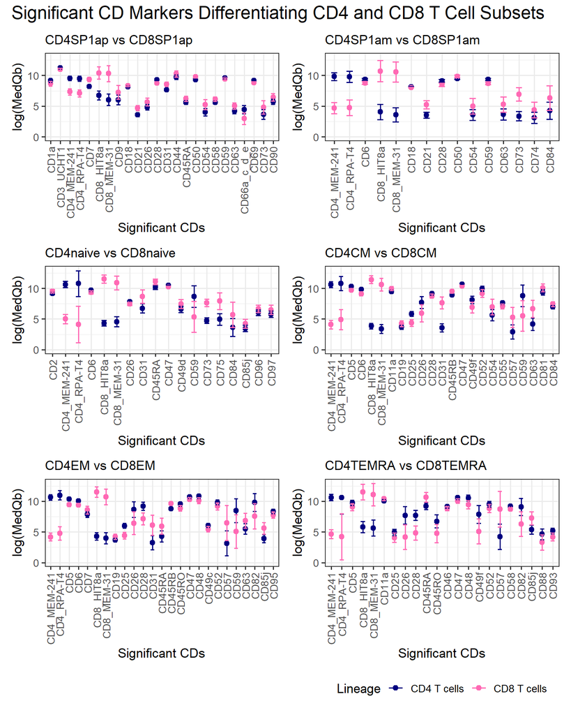

```r
p1 <- data_analysis5 |>
  CD_order() |>
  plot_CD4vsCD8(pair_filter = "SP1ap",
                legend_position = "none")

p2 <- data_analysis5 |>
  CD_order() |>
  plot_CD4vsCD8(pair_filter = "SP1am",
                legend_position = "none")

p3 <- data_analysis5 |>
  CD_order() |>
  plot_CD4vsCD8(pair_filter = "naive",
                legend_position = "none")

p4 <- data_analysis5 |>
  CD_order() |>
  plot_CD4vsCD8(pair = "CM",
                legend_position = "none")

p5 <- data_analysis5 |>
  CD_order() |>
  plot_CD4vsCD8(pair_filter = "EM",
                legend_position = "none")

p6 <- data_analysis5 |>
  CD_order() |>
  plot_CD4vsCD8(pair_filter = "TEMRA",
                legend_position = "bottom")

(p1 + p2) / (p3 + p4) / (p5 + p6) +
  plot_annotation(
    title = "Significant CD Markers Differentiating CD4 and CD8 T Cell Subsets") &
  theme(plot.title = element_text(size = 18))
```

## Overview of CDs

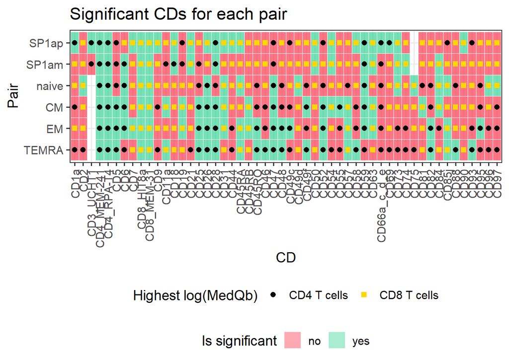

```r
final_plot <- data_analysis5 |>
  CD_order() |>
  group_by(CD)|>
  filter(any(is_significant == "yes")) |>
  ungroup() |>
  group_by(CD, pair) |>
  mutate(highest = if_else(
    estimate[str_detect(cell_type, "CD8")] >
    estimate[str_detect(cell_type, "CD4")],
    "CD8 T cells",
    "CD4 T cells")) |>
  mutate(pair = factor(x = pair,
                       levels = c("TEMRA",
                                  "EM",
                                  "CM",
                                  "naive",
                                  "SP1am",
                                  "SP1ap"))) |>
  ggplot(aes(x = CD,
             y = pair)) +
  geom_tile(aes(fill = is_significant),
            alpha = 0.4,
            color = "white") +
  geom_point(aes(shape = highest,
                 color = highest,),
             size = 2) +
  scale_fill_manual(values = c("no" = "#fa2840",
                                "yes" = "#29cf8f")) +
  scale_color_manual(values = c("CD4 T cells" = "black",
                               "CD8 T cells" = "#FFD700")) +
  scale_shape_manual(values = c("CD4 T cells" = 16,
                                "CD8 T cells" = 15)) +
  theme_bw(base_size = 14) +
  theme(axis.text.x = element_text(angle = 90,
                                    vjust = 0.5,
                                    hjust = 1),
        legend.position = "bottom",
        legend.box = "vertical") +
  labs(title = "Significant CDs for each pair",
       fill = "Is significant",
       shape = "Highest log(MedQb)",
       color = "Highest log(MedQb)",
       x = "CD",
       y = "Pair")

final_plot
```

## Plot export

```r
save_plot(plot = sig_CD_count,
          filename = "09_key_plot_1.png")

save_plot(plot = final_plot,
          filename = "09_key_plot_2.png",
          width = 10,
          height = 5)
```